# Clear-air turbulence indicators — how the dataset is made

This notebook is the **showcase** of the pipeline in `essentials/`: what is computed, from what, with which formula, and what the result looks like. It runs on **one day** of ERA5 (8 time steps) in about a minute, on a laptop. It does **not** recompute the dataset — the 42-year series on ADA stays exactly as it is, and the trend figures in §7 are read from the result files already in this repository.

Every number below is produced by importing `essentials/*.py` — the same code that produced the dataset on the cluster. Nothing is re-typed here, so the notebook cannot drift from the pipeline: the formulas you see printed are the running code.

| **Stage 1** | ERA5 on the CDS → one GRIB file per month (`download.py`) |
| --- | --- |
| **Stage 2** | 21 turbulence diagnostics at 200 hPa (`diagnostics.py`) — §1–§5 below |
| **Stage 3** | severity thresholds from the global year 2000 (`thresholds.py`) — §6 |
| **Stage 4** | exceedance → seasonal frequency → 1979–2020 trend (`trends.py`) — §7 |

Why each choice was made: `DECISIONS.md` next to this notebook. What was verified and how: §8.

## 0. Setup

The only inputs are one ERA5 file and (for §7) the CSVs in `data_prosser/`. If the day file is somewhere else, set `CAT_DEMO_FILE` or edit `CANDIDATES` below.

```python
import os, sys, inspect, json
from pathlib import Path
import numpy as np, xarray as xr
import matplotlib.pyplot as plt

HERE = Path.cwd()                     # run this notebook from essentials/
sys.path.insert(0, str(HERE))
import config as C, diagnostics as D, thresholds as T, trends as TR

# --- the demo file: one day, North Atlantic box, 8 three-hourly steps ----------
CANDIDATES = [
    os.environ.get("CAT_DEMO_FILE", ""),
    "../../../Universiteit/Turbulence project/Data/climate_data_01_01_2016.grib",
    "../era5_validation_subset.nc",   # fallback: the small NetCDF in the repo
]
DEMO = next(Path(p) for p in CANDIDATES if p and Path(p).exists())

# --- the convention: change this line and re-run the notebook -----------------
CONVENTION = "audit"                  # "audit" or "baseline"; see section 5
conv = C.CONVENTIONS[CONVENTION]

print("file       :", DEMO.name)
print("convention :", CONVENTION, conv)
```

```
file       : climate_data_01_01_2016.grib
convention : audit {'dy': 'map', 'fields': 'computed', 'f2d_variant': 'A', 'endlich': 'angle'}
```

```python
# House style for the figures in this notebook.
plt.rcParams.update({"figure.dpi": 110, "font.size": 9, "axes.grid": False,
                     "axes.spines.top": False, "axes.spines.right": False})
BLUE, ORANGE, AQUA, GREY = "#2a78d6", "#eb6834", "#1baf7a", "#8a8a85"

def plot_map(field, title, ax=None, diverging=False, log=False, cbar_label=""):
    # One (latitude, longitude) field. Sequential colours unless the field is signed.
    a = np.asarray(field)
    if log:
        a = np.log10(np.abs(a) + 1e-30)
    ax = ax or plt.subplots(figsize=(6, 2.8))[1]
    lo, hi = np.nanpercentile(a, [1, 99])
    if diverging:
        hi = max(abs(lo), abs(hi)); lo = -hi
        cmap = "RdBu_r"
    else:
        cmap = "cividis"              # perceptually uniform, colour-vision safe
    im = ax.pcolormesh(field.longitude, field.latitude, a, vmin=lo, vmax=hi,
                       cmap=cmap, shading="auto", rasterized=True)
    ax.set_title(title, fontsize=9, loc="left")
    ax.set_xlabel("longitude"); ax.set_ylabel("latitude")
    cb = plt.colorbar(im, ax=ax, pad=0.02, fraction=0.045)
    cb.set_label(cbar_label or ("log10 |value|" if log else ""), fontsize=8)
    return ax

def source_of(fn):
    # Print a function exactly as it runs in the pipeline.
    print(inspect.getsource(fn))
```

## 1. The input data

One month of ERA5 is one GRIB file: **7 variables × 3 pressure levels × 8 steps per day**, on the 0.25° grid, over 30–60°N / 75–0°W.

| field | symbol | why it is downloaded |
| --- | --- | --- |
| `u`, `v` | $u, v$ | the wind; 18 of the 21 diagnostics need it |
| `t` | $T$ | temperature → potential temperature $\theta$, static stability |
| `z` | $\Phi = g Z$ | geopotential → the height of each pressure level, so $\partial/\partial z$ is real |
| `d`, `vo`, `pv` | $\delta, \zeta, \mathrm{PV}$ | ERA5's own divergence, vorticity and potential vorticity — used only by the `baseline` convention (§5) |

The three levels **175 / 200 / 225 hPa** exist so that the vertical derivatives at 200 hPa have a centred stencil. Everything is evaluated at **200 hPa**; the other two levels never leave this stage.

```python
raw = D.open_era5(DEMO)
prepared = D.prepare(raw)             # names, longitudes, altitude coordinate, dimension order
print(prepared.sizes)
print("levels    :", prepared.pressure_level.values, "hPa")
print("times     :", str(prepared.time.values[0])[:16], "...", str(prepared.time.values[-1])[:16])
prepared[["eastward_wind", "northward_wind", "temperature", "geopotential"]]
```

```
Frozen({'time': 8, 'pressure_level': 3, 'latitude': 121, 'longitude': 301})
levels    : [225. 200. 175.] hPa
times     : 2016-01-01T00:00 ... 2016-01-01T21:00
```

```
<xarray.Dataset> Size: 14MB
Dimensions:         (latitude: 121, longitude: 301, time: 8, pressure_level: 3)
Coordinates:
  * latitude        (latitude) float64 968B 60.0 59.75 59.5 ... 30.5 30.25 30.0
  * longitude       (longitude) float64 2kB -75.0 -74.75 -74.5 ... -0.25 0.0
  * time            (time) datetime64[ns] 64B 2016-01-01 ... 2016-01-01T21:00:00
    valid_time      (time) datetime64[ns] 64B ...
  * pressure_level  (pressure_level) float64 24B 225.0 200.0 175.0
    altitude        (pressure_level) float64 24B 1.104e+04 1.177e+04 1.259e+04
    number          int64 8B ...
    step            timedelta64[ns] 8B ...
Data variables:
    eastward_wind   (latitude, longitude, time, pressure_level) float32 3MB ...
    northward_wind  (latitude, longitude, time, pressure_level) float32 3MB ...
    temperature     (latitude, longitude, time, pressure_level) float32 3MB ...
    geopotential    (latitude, longitude, time, pressure_level) float32 3MB ...
Attributes:
    GRIB_edition:            1
    GRIB_centre:             ecmf
    GRIB_centreDescription:  European Centre for Medium-Range Weather Forecasts
    GRIB_subCentre:          0
    Conventions:             CF-1.7
    institution:             European Centre for Medium-Range Weather Forecasts
    history:                 2026-09-21T08:39 GRIB to CDM+CF via cfgrib-0.9.1...
```

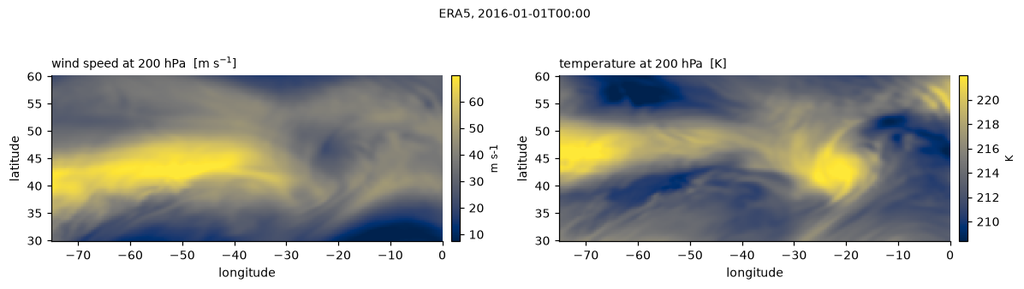

```python
t0, lev = 0, C.TARGET_LEVEL_HPA
fig, axes = plt.subplots(1, 2, figsize=(11, 2.9))
speed = np.hypot(prepared.eastward_wind, prepared.northward_wind).isel(time=t0).sel(pressure_level=lev)
plot_map(speed, f"wind speed at {lev} hPa  [m s$^{{-1}}$]", axes[0], cbar_label="m s-1")
plot_map(prepared.temperature.isel(time=t0).sel(pressure_level=lev),
         f"temperature at {lev} hPa  [K]", axes[1], cbar_label="K")
fig.suptitle(f"ERA5, {str(prepared.time.values[t0])[:16]}", y=1.04, fontsize=9)
plt.tight_layout();
```

## 2. The grid: from degrees to metres

Every diagnostic is built from derivatives in **metres**, but the data sits on a latitude–longitude grid. The pipeline treats the grid as a flat map with coordinates $X = a\lambda$, $Y = a\varphi$ ($a$ = WGS84 equatorial radius), takes finite differences in $X$ and $Y$, and converts them with the two map-scale factors

$$\frac{\partial}{\partial x} = k_x \frac{\partial}{\partial X},\qquad \frac{\partial}{\partial y} = k_y \frac{\partial}{\partial Y},\qquad k_x = \frac{a}{N(\varphi)\cos\varphi},\qquad k_y = \frac{a}{M(\varphi)},$$

with $N$ and $M$ the prime-vertical and meridional radii of curvature of the ellipsoid,

$$N = \frac{a}{\sqrt{1-e^2\sin^2\varphi}},\qquad M = \frac{a(1-e^2)}{(1-e^2\sin^2\varphi)^{3/2}}.$$

$k_x$ grows as $1/\cos\varphi$: at 60°N a degree of longitude is half the distance it is at the equator, and the derivative has to know that.

**This is where the two conventions first differ** (§5). `dy` is either the true meridian arc $M\,\Delta\varphi$ (`baseline`, what MetPy and rojak use) or the map distance $a\,\Delta\varphi$ (`audit`). In the first case the factor $a/M$ is applied to a distance that already carries $M$ — the ellipsoid correction lands twice, a latitude-dependent error of a few tenths of a per cent in every north–south derivative.

```python
source_of(D.grid_geometry)
```

```
def grid_geometry(latitude, longitude, dy_method: str) -> dict:
    """Grid spacings and map-scale factors for a regular lat-lon grid.

    The grid is treated as a map (plate carree) with coordinates
        X = a * lam,        Y = a * phi         (a = WGS84 equatorial radius)
    so a finite difference along the grid is a derivative with respect to X or
    Y. A physical derivative on the ellipsoid then follows by multiplying by a
    map-scale factor:

        d/dx = k_x d/dX,   k_x = a / (N(phi) cos phi)      (parallel scale)
        d/dy = k_y d/dY,   k_y = a / M(phi)                (meridional scale)

    with N and M the prime-vertical and meridional radii of curvature,
        N = a / sqrt(1 - e^2 sin^2 phi),   M = a (1 - e^2) / (1 - e^2 sin^2 phi)^(3/2).

    k_x and k_y are taken from PROJ (`+proj=latlon`), exactly as rojak/MetPy
    do. PROJ evaluates them numerically; they agree with the closed forms above
    to ~1e-11 (tests/test_operators.py), and at the poles PROJ returns a large
    finite k_x (~1e5) instead of infinity.

    dx = a * dlam between neighbouring columns (identical to the geodesic
    distance along the equator that rojak uses).

    dy depends on the convention -- this is audit fix F1:
      "geodesic"  dy = the true meridian arc between rows (~ M dphi), which is
                  what rojak/MetPy use. Multiplying that by k_y = a/M applies
                  the ellipsoid correction twice: a latitude-dependent error of
                  +0.42 % at 30N to -0.27 % at 75N in every d/dy.
      "map"       dy = a * dphi, the map distance, so k_y is applied once.
                  Error against exact ellipsoidal gradients: 2e-7.
    dy is negative because ERA5 latitudes run north to south.

    Also returned: dk_x/dY and dk_y/dX, the rate at which the scale factors
    change across the grid. They are the curvature terms in wind_derivatives.
    """
    lat = np.asarray(latitude, dtype=float)
    lon = np.asarray(longitude, dtype=float)

    dx = C.A_WGS84 * np.deg2rad(np.abs(np.diff(lon)))
    if dy_method == "map":
        dy = C.A_WGS84 * np.deg2rad(np.diff(lat))
    elif dy_method == "geodesic":
        zeros = np.zeros_like(lat)
        azimuth, _, dy = Geod(ellps="WGS84").inv(zeros[:-1], lat[:-1], zeros[1:], lat[1:])
        dy[(azimuth < -90.0) | (azimuth > 90.0)] *= -1      # southward step -> negative
    else:
        raise ValueError(f"dy_method must be 'map' or 'geodesic', got {dy_method!r}")

    lon_grid, lat_grid = np.meshgrid(lon, lat)
    factors = Proj(CRS("+proj=latlon")).get_factors(lon_grid, lat_grid)
    coords = {"latitude": latitude, "longitude": longitude}
    k_x = xr.DataArray(factors.parallel_scale, dims=("latitude", "longitude"), coords=coords)
    k_y = xr.DataArray(factors.meridional_scale, dims=("latitude", "longitude"), coords=coords)

    geo = {"dx": dx, "dy": dy, "k_x": k_x, "k_y": k_y}
    geo["dkx_dY"] = grid_difference(k_x, dy, "latitude")
    geo["dky_dX"] = grid_difference(k_y, dx, "longitude")
    return geo
```

```
dx = 27,829.9 m  (0.25° of longitude at the equator)
dy = -27,829.9 m (audit)   -27,852.5 m (baseline)
```

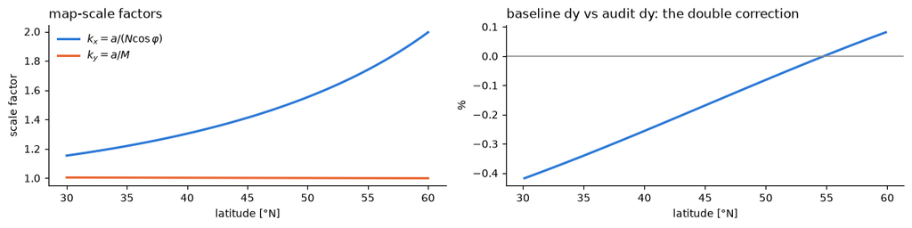

```python
lat = prepared.latitude.values
geo_map = D.grid_geometry(lat, prepared.longitude.values, "map")
geo_geo = D.grid_geometry(lat, prepared.longitude.values, "geodesic")

fig, axes = plt.subplots(1, 2, figsize=(11, 2.8))
axes[0].plot(lat, geo_map["k_x"].values[:, 0], color=BLUE, lw=2, label="$k_x = a/(N\\cos\\varphi)$")
axes[0].plot(lat, geo_map["k_y"].values[:, 0], color=ORANGE, lw=2, label="$k_y = a/M$")
axes[0].set_xlabel("latitude [°N]"); axes[0].set_ylabel("scale factor")
axes[0].set_title("map-scale factors", loc="left"); axes[0].legend(frameon=False)

mid = 0.5 * (lat[:-1] + lat[1:])
axes[1].plot(mid, 100 * (geo_geo["dy"] / geo_map["dy"] - 1), color=BLUE, lw=2)
axes[1].axhline(0, color=GREY, lw=1)
axes[1].set_xlabel("latitude [°N]"); axes[1].set_ylabel("%")
axes[1].set_title("baseline dy vs audit dy: the double correction", loc="left")
plt.tight_layout()
print(f"dx = {geo_map['dx'][0]:,.1f} m  (0.25° of longitude at the equator)")
print(f"dy = {geo_map['dy'][0]:,.1f} m (audit)   {geo_geo['dy'][0]:,.1f} m (baseline)")
```

## 3. The four operators everything is built from

**Horizontal difference.** Second-order centred inside the domain, one-sided at the edge, on the cumulative grid distance — `np.gradient`, the same call rojak/MetPy make.

**Gradient of a scalar** (temperature, geopotential, vorticity): $\nabla_H f = (k_x\,\partial f/\partial X,\; k_y\,\partial f/\partial Y)$.

**Derivatives of the wind** are *not* that. The east and north unit vectors rotate as you move over the sphere, which adds curvature terms:

$$\frac{\partial u}{\partial x} = k_x\frac{\partial u}{\partial X} - v\,\frac{k_y}{k_x}\frac{\partial k_x}{\partial Y}, \qquad \frac{\partial v}{\partial x} = k_x\frac{\partial v}{\partial X} + u\,\frac{k_y}{k_x}\frac{\partial k_x}{\partial Y},$$

and likewise in $y$. On a sphere $\frac{k_y}{k_x}\frac{\partial k_x}{\partial Y} = \tan\varphi/R$, so a purely zonal wind with no shear at all still has vorticity $u\tan\varphi/R$. Leaving the terms out makes the vorticity wrong by 100 % and the Laplacian of $\Phi$ wrong by 99 %. The cell below demonstrates it.

**Vertical derivative.** Pressure levels are not equally spaced in height, so the chain rule goes through the geopotential itself: $$\frac{\partial f}{\partial z} = g\,\frac{\partial f/\partial p}{\partial \Phi/\partial p}.$$

```python
source_of(D.wind_derivatives)
```

```
def wind_derivatives(u: xr.DataArray, v: xr.DataArray, geo: dict) -> dict:
    """The four horizontal derivatives of a VECTOR field (u, v) on the sphere.

    Differentiating a vector component is not the same as differentiating a
    scalar: the local east/north unit vectors rotate as you move, which adds
    curvature terms (MetPy's `vector_derivative`):

        du/dx = k_x du/dX - v * (k_y/k_x) dk_x/dY
        du/dy = k_y du/dY + v * (k_x/k_y) dk_y/dX
        dv/dx = k_x dv/dX + u * (k_y/k_x) dk_x/dY
        dv/dy = k_y dv/dY - u * (k_x/k_y) dk_y/dX

    On a sphere (k_y/k_x) dk_x/dY = tan(phi)/R, so e.g. a purely zonal flow
    with no shear still has vorticity u tan(phi)/R. Without these terms the
    vorticity is 100 % wrong (Stokes' theorem test, STATUS 4g).
    dk_y/dX is zero on this grid, so the last terms vanish in practice.

    Standing rule: any derivative OF u or v, and any divergence of a vector,
    goes through this function -- never through d_dx / d_dy.
    """
    k_x, k_y = geo["k_x"], geo["k_y"]
    x_curv = (k_y / k_x) * geo["dkx_dY"]
    y_curv = (k_x / k_y) * geo["dky_dX"]
    return {
        "du_dx": k_x * grid_difference(u, geo["dx"], "longitude") - v * x_curv,
        "du_dy": k_y * grid_difference(u, geo["dy"], "latitude") + v * y_curv,
        "dv_dx": k_x * grid_difference(v, geo["dx"], "longitude") + u * x_curv,
        "dv_dy": k_y * grid_difference(v, geo["dy"], "latitude") - u * y_curv,
    }
```

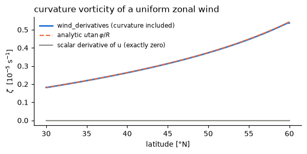

```python
# A uniform 20 m/s eastward wind: no shear anywhere, yet it has vorticity.
lon = prepared.longitude.values
ones = xr.DataArray(np.full((lat.size, lon.size), 20.0), dims=("latitude", "longitude"),
                    coords={"latitude": lat, "longitude": lon})
zero = xr.zeros_like(ones)
wd = D.wind_derivatives(ones, zero, geo_map)
zeta = (wd["dv_dx"] - wd["du_dy"]).values[:, 5]
analytic = 20.0 * np.tan(np.deg2rad(lat)) / 6.371e6

fig, ax = plt.subplots(figsize=(5.5, 2.8))
ax.plot(lat, 1e5 * zeta, color=BLUE, lw=2, label="wind_derivatives (curvature included)")
ax.plot(lat, 1e5 * analytic, color=ORANGE, lw=1.5, ls="--", label=r"analytic $u\tan\varphi/R$")
ax.plot(lat, 1e5 * D.d_dy(ones, geo_map).values[:, 5] * 0, color=GREY, lw=1.5,
        label="scalar derivative of u (exactly zero)")
ax.set_xlabel("latitude [°N]"); ax.set_ylabel(r"$\zeta$  [$10^{-5}$ s$^{-1}$]")
ax.set_title("curvature vorticity of a uniform zonal wind", loc="left")
ax.legend(frameon=False, fontsize=8); plt.tight_layout();
```

## 4. The 21 diagnostics

Each one is a short function whose docstring carries its formula and its equation number in Sharman et al. (2006) Appendix A. They share five building blocks, computed once:

$$D_{sh} = \frac{\partial v}{\partial x} + \frac{\partial u}{\partial y},\qquad D_{st} = \frac{\partial u}{\partial x} - \frac{\partial v}{\partial y},\qquad \mathrm{DEF} = \sqrt{D_{sh}^2 + D_{st}^2},$$

$$S_v = \left|\frac{\partial \mathbf{V}}{\partial z}\right| = \sqrt{\left(\frac{\partial u}{\partial z}\right)^2+\left(\frac{\partial v}{\partial z}\right)^2}, \qquad N^2 = \frac{g}{\theta}\frac{\partial \theta}{\partial z}, \qquad \theta = T\left(\frac{p_0}{p}\right)^{R/c_p},$$

with $\zeta$ the relative vorticity, $f = 2\Omega\sin\varphi$ the Coriolis parameter and $\zeta_a = \zeta + f$.

```python
geo = D.grid_geometry(prepared.latitude, prepared.longitude, conv["dy"])
blocks = D.building_blocks(prepared, geo, conv)
fields = D.compute_21(prepared, conv)          # all 21, at 200 hPa
print(f"{len(fields)} diagnostics, each {dict(fields['ti1'].sizes)}")
```

```
21 diagnostics, each {'latitude': 121, 'longitude': 301, 'time': 8}
```

```python
def show(key, log=True, diverging=False):
    # Print the function as it runs, then map it for the first time step.
    source_of(getattr(D, key))
    field = fields[key].isel(time=0)
    q = np.nanpercentile(field.values, [50, 97, 99.9])
    print(f"median {q[0]:.4g}   p97 {q[1]:.4g}   p99.9 {q[2]:.4g}   "
          f"NaN {100*np.isnan(field.values).mean():.2f} %")
    plot_map(field, f"{key} — {str(field.time.values)[:16]}", log=log, diverging=diverging)
    plt.show()
```

### 4.1 `magnitude_pv`

$$|\mathrm{PV}|,\qquad \mathrm{PV} = -g\,\zeta_a\,\partial\theta/\partial p \;\text{(A18)}$$

Low potential vorticity marks unbalanced flow. Under `audit` this is Sharman's truncated form; under `baseline` it is ERA5's full Ertel PV.

```
def magnitude_pv(s):
    """[1] |PV|. Archived: |full Ertel PV|. Computed: |-g (zeta+f) dtheta/dp| (A18)."""
    return np.abs(s["pv"])

median 0.0005268   p97 0.0008146   p99.9 0.0008792   NaN 0.00 %
```

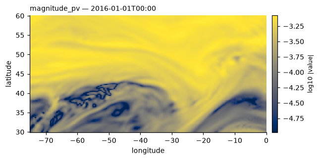

```python
show("magnitude_pv", log=True, diverging=False)
```

### 4.2 `colson_panofsky`

$$\mathrm{CP} = \lambda^2\left(S_v^2 - N^2/\mathrm{Ri}_c\right),\quad \mathrm{Ri}_c = 0.5$$

Shear that is large compared with the stability that would suppress it. $\lambda$ is the layer thickness, a constant here.

```
def colson_panofsky(s):
    """[2] Colson-Panofsky index (A4), in its reduced form

        CP = lambda^2 (Sv^2 - N^2 / Ri_crit),       Ri_crit = 0.5

    which equals lambda^2 Sv^2 (1 - Ri/Ri_crit) without forming Ri. lambda is the
    ICAO height difference between 200 and 225 hPa: a constant.
    """
    alt = s["ds"]["altitude"]
    lam = alt.diff("pressure_level", label="upper").sel(pressure_level=s["lev"])
    return np.square(lam) * (_at(s["Sv2"], s) - _at(s["N2"], s) / C.RI_CRIT)

median -399.2   p97 -131.7   p99.9 -69.92   NaN 0.00 %
```

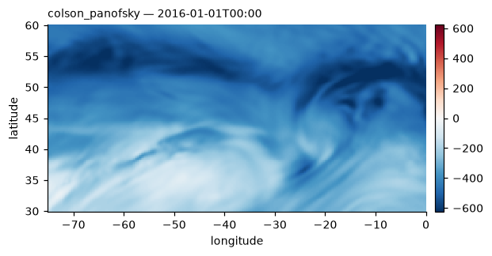

```python
show("colson_panofsky", log=False, diverging=True)
```

### 4.3 `brown1`

$$\Phi = \sqrt{0.3\,\zeta_a^2 + D_{sh}^2 + D_{st}^2}$$

Brown's simplification of the Richardson-tendency equation.

```
def brown1(s):
    """[3] Brown index (A13): Phi = sqrt(0.3 zeta_a^2 + D_sh^2 + D_st^2), zeta_a = zeta + f."""
    zeta_a = s["zeta"] + coriolis(s["zeta"]["latitude"])
    return np.sqrt(0.3 * np.square(zeta_a) + np.square(s["D_sh"]) + np.square(s["D_st"]))

median 7.629e-05   p97 0.0001249   p99.9 0.0001786   NaN 0.00 %
```

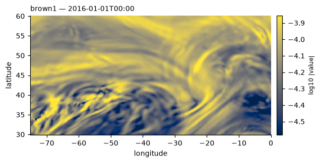

```python
show("brown1", log=True, diverging=False)
```

### 4.4 `temperature_gradient`

$$|\nabla_H T| = \sqrt{(\partial T/\partial x)^2 + (\partial T/\partial y)^2}$$

A front, in one number.

```
def temperature_gradient(s):
    """[4] |grad_H T| = sqrt((dT/dx)^2 + (dT/dy)^2)   (A23)."""
    return np.hypot(d_dx(s["T"], s["geo"]), d_dy(s["T"], s["geo"]))

median 8.216e-06   p97 2.595e-05   p99.9 4.442e-05   NaN 0.00 %
```

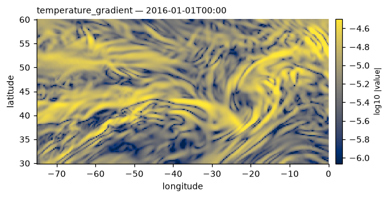

```python
show("temperature_gradient", log=True, diverging=False)
```

### 4.5 `horizontal_divergence`

$$|\delta| = |\partial u/\partial x + \partial v/\partial y|$$

Stretching and squeezing of the flow.

```
def horizontal_divergence(s):
    """[5] |delta|, delta = du/dx + dv/dy   (A33). Archived ERA5 d, or computed (convention)."""
    return np.abs(s["delta"])

median 1.26e-05   p97 6.633e-05   p99.9 0.0001424   NaN 0.00 %
```

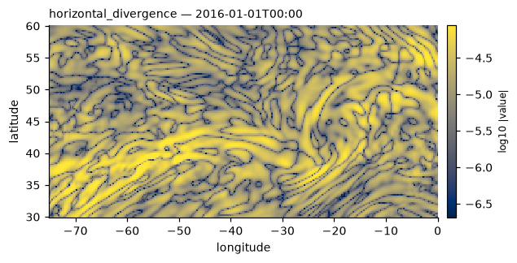

```python
show("horizontal_divergence", log=True, diverging=False)
```

### 4.6 `vertical_wind_shear`

$$S_v = \sqrt{(\partial u/\partial z)^2 + (\partial v/\partial z)^2}$$

The classic ingredient: shear across the layer.

```
def vertical_wind_shear(s):
    """[6] Sv = |dV/dz| = sqrt((du/dz)^2 + (dv/dz)^2)   (A3)."""
    return s["Sv"]

median 0.003707   p97 0.01014   p99.9 0.01568   NaN 0.00 %
```

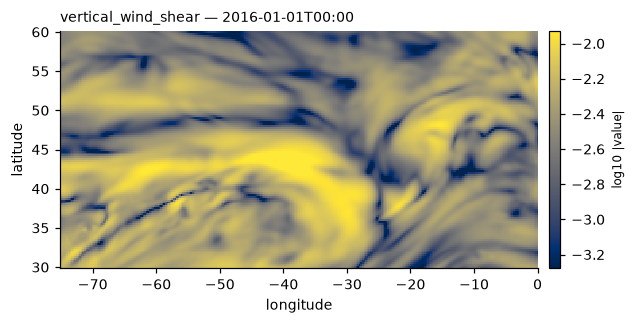

```python
show("vertical_wind_shear", log=True, diverging=False)
```

### 4.7 `endlich`

$$|\mathbf{V}|\,\left|\partial \psi/\partial z\right|,\quad \psi = \text{wind direction}$$

Speed times how fast the wind *turns* with height. The one diagnostic whose finite difference is an angle.

```
def endlich(s):
    """[7] Endlich index (A25): |V| * |d psi / dz|, psi = wind direction.

    "angle":      |d psi/dz| = g * |wrapped psi difference / dp| / (dPhi/dp)
    "components": |d psi/dz| = |u dv/dz - v du/dz| / |V|^2  (exact for psi = atan2)
    The two are different estimators on a 50 hPa stencil (audit F10).
    """
    u, v, z = s["u"], s["v"], s["z"]
    if s["conv"]["endlich"] == "angle":
        dpsi_dz = C.G * d_angle_dp(wind_direction(u, v)) / d_dp(z)
        return np.hypot(u, v) * np.abs(dpsi_dz)
    speed = np.hypot(u, v)
    return np.abs(u * s["dv_dz"] - v * s["du_dz"]) / xr.where(speed > 0, speed, np.nan)

median 0.001769   p97 0.007267   p99.9 0.01   NaN 0.00 %
```

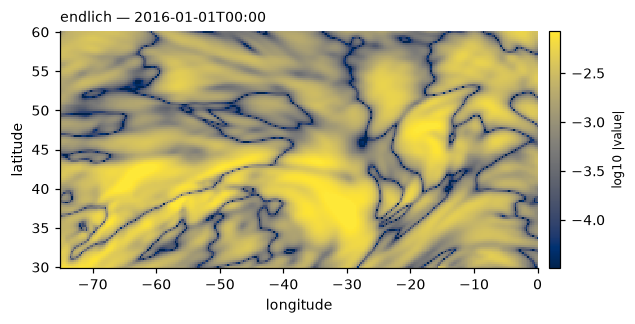

```python
show("endlich", log=True, diverging=False)
```

### 4.8 `deformation`

$$\mathrm{DEF} = \sqrt{D_{sh}^2 + D_{st}^2}$$

How strongly the flow stretches a parcel.

```
def deformation(s):
    """[8] DEF = sqrt(D_sh^2 + D_st^2)  (A17), D_sh = dv/dx + du/dy, D_st = du/dx - dv/dy.

    Written as sqrt(|DEF^2|) because that is how the original pipeline undid
    rojak's squared output; kept so the stored numbers are bit-identical.
    """
    return np.sqrt(np.abs(np.square(s["DEF"])))

median 3.792e-05   p97 0.0001032   p99.9 0.0001702   NaN 0.00 %
```

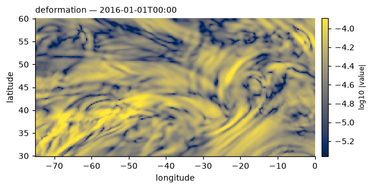

```python
show("deformation", log=True, diverging=False)
```

### 4.9 `wind_speed`

$$|\mathbf{V}| = \sqrt{u^2+v^2}$$

The jet itself.

```
def wind_speed(s):
    """[9] |V| = sqrt(u^2 + v^2)   (A24)."""
    return np.hypot(s["u"], s["v"])

median 37.7   p97 67.44   p99.9 73.94   NaN 0.00 %
```

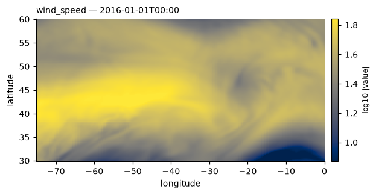

```python
show("wind_speed", log=True, diverging=False)
```

### 4.10 `ngm2`

$$\left|\partial T/\partial z\right| \cdot \mathrm{DEF}$$

Deformation weighted by vertical temperature structure.

```
def ngm2(s):
    """[10] NGM2 = |dT/dz| * DEF   (A29)."""
    return np.abs(d_dz(s["T"], s["z"])) * s["DEF"]

median 6.809e-08   p97 4.872e-07   p99.9 9.809e-07   NaN 0.00 %
```

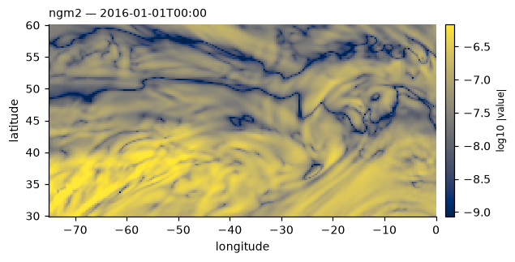

```python
show("ngm2", log=True, diverging=False)
```

### 4.11 `negative_richardson`

$$-\mathrm{Ri} = -\,N^2/S_v^2$$

Small (or negative) Richardson number = Kelvin–Helmholtz instability; the minus makes 'more turbulent' mean 'larger'.

```
def negative_richardson(s):
    """[11] -Ri, with the gradient Richardson number Ri = N^2 / Sv^2  (A1)."""
    return -(s["N2"] / s["Sv2"])

median -25.32   p97 -2.988   p99.9 -1.55   NaN 0.00 %
```

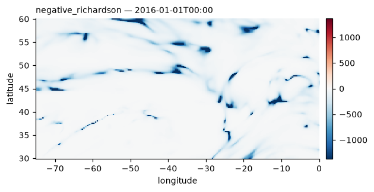

```python
show("negative_richardson", log=False, diverging=True)
```

### 4.12 `rva_magnitude`

$$\left|u\,\partial\zeta/\partial x + v\,\partial\zeta/\partial y\right|$$

Advection of relative vorticity.

```
def rva_magnitude(s):
    """[12] |relative vorticity advection| = |u dzeta/dx + v dzeta/dy|
    (Williams & Joshi 2013; not in Sharman Appendix A)."""
    zeta = _at(s["zeta"], s)
    return np.abs(_at(s["u"], s) * d_dx(zeta, s["geo"]) + _at(s["v"], s) * d_dy(zeta, s["geo"]))

median 2.671e-09   p97 1.99e-08   p99.9 5.778e-08   NaN 0.00 %
```

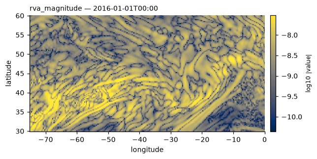

```python
show("rva_magnitude", log=True, diverging=False)
```

### 4.13 `ubf`

$$\left|\nabla^2\Phi - 2J(u,v) - f\zeta + \beta u\right|$$

The residual of the nonlinear balance equation: how far the flow is from balance. A near-cancellation of large terms, so the geometry of §3 matters most here.

```
def ubf(s):
    """[13] Unbalanced flow (A30, Koch & Caracena 2002): the residual of the
    nonlinear balance equation

        UBF = | lap(Phi) - 2 J(u,v) - f zeta + beta u |

    lap(Phi) = divergence of grad(Phi)   (a vector divergence: wind_derivatives)
    J(u,v)   = du/dx dv/dy - du/dy dv/dx
    beta     = df/dy = 2 Omega cos(phi) / R
    """
    geo, lev = s["geo"], s["lev"]
    u, zeta, phi = _at(s["u"], s), _at(s["zeta"], s), _at(s["z"], s)
    lat_rad = np.deg2rad(s["ds"]["latitude"])
    f = (2 * C.OMEGA * np.sin(lat_rad)).broadcast_like(u.isel(time=0))
    beta = (2 * C.OMEGA * np.cos(lat_rad) / C.R_EARTH).broadcast_like(u.isel(time=0))

    grad_phi = wind_derivatives(d_dx(phi, geo), d_dy(phi, geo), geo)
    laplacian = grad_phi["du_dx"] + grad_phi["dv_dy"]
    wd = {k: w.sel(pressure_level=lev) for k, w in s["wd"].items()}
    jacobian = wd["du_dx"] * wd["dv_dy"] - wd["du_dy"] * wd["dv_dx"]

    return np.abs(laplacian - 2 * jacobian - f * zeta + beta * u)

median 4.499e-09   p97 2.614e-08   p99.9 6.723e-08   NaN 0.00 %
```

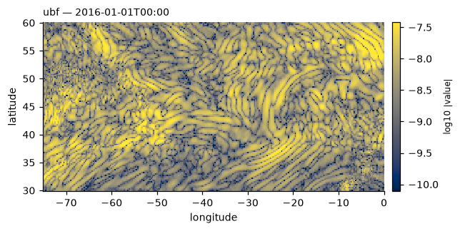

```python
show("ubf", log=True, diverging=False)
```

### 4.14 `nva`

$$\max\left(-\,\mathbf{V}\cdot\nabla(\zeta+f),\; 0\right)$$

Negative advection of absolute vorticity, one-sided by definition.

```
def nva(s):
    """[14] Negative absolute vorticity advection (A37):
        NVA = max( -(u d(zeta+f)/dx + v d(zeta+f)/dy), 0 )."""
    zeta_a = s["zeta"] + coriolis(s["zeta"]["latitude"])
    advection_x = s["u"] * d_dx(zeta_a, s["geo"])
    advection_y = s["v"] * d_dy(zeta_a, s["geo"])
    return (-advection_x - advection_y).clip(min=0)

median 9.512e-11   p97 1.412e-08   p99.9 4.205e-08   NaN 0.00 %
```

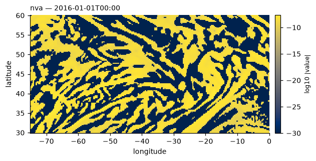

```python
show("nva", log=True, diverging=False)
```

### 4.15 `brown2`

$$\varepsilon = \tfrac{1}{24}\,\Phi\,S_v^2$$

Brown's energy-dissipation rate. Kept in its native units — the published table implies a length² that Sharman's equation does not contain, and a constant factor cannot change a percentile.

```
def brown2(s, brown1_value):
    """[15] Brown energy dissipation rate (A14): eps = Phi * Sv^2 / 24.
    Units s-3 (the published m2 s-3 implies an unstated length^2; constant)."""
    return (1.0 / 24.0) * brown1_value * s["Sv2"]

median 3.923e-11   p97 3.143e-10   p99.9 6.951e-10   NaN 0.00 %
```

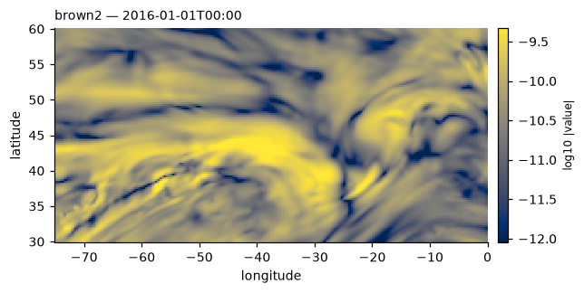

```python
show("brown2", log=True, diverging=False)
```

### 4.16 `vorticity_squared`

$$\zeta^2$$

Rotation, squared.

```
def vorticity_squared(s):
    """[16] zeta^2   (A21). Archived or computed zeta (convention)."""
    return np.square(s["zeta"])

median 1e-09   p97 7.305e-09   p99.9 1.417e-08   NaN 0.00 %
```

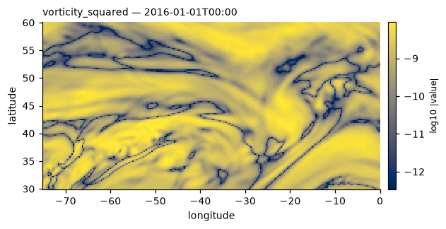

```python
show("vorticity_squared", log=True, diverging=False)
```

### 4.17 `ti1`

$$\mathrm{TI1} = S_v\,\mathrm{DEF}$$

Ellrod's index 1: the workhorse of operational CAT forecasting.

```
def ti1(s):
    """[17] Ellrod TI1 = Sv * DEF   (A15)."""
    return s["Sv"] * s["DEF"]

median 1.252e-07   p97 6.686e-07   p99.9 1.215e-06   NaN 0.00 %
```

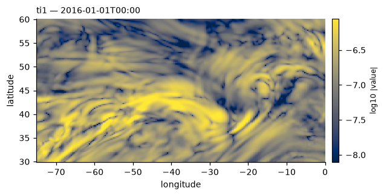

```python
show("ti1", log=True, diverging=False)
```

### 4.18 `ngm1`

$$|\mathbf{V}|\,\mathrm{DEF}$$

Deformation weighted by speed.

```
def ngm1(s):
    """[18] NGM1 = |V| * DEF   (A28)."""
    return np.hypot(s["u"], s["v"]) * s["DEF"]

median 0.001346   p97 0.004805   p99.9 0.009187   NaN 0.00 %
```

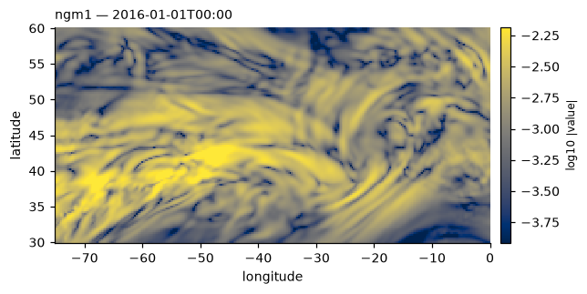

```python
show("ngm1", log=True, diverging=False)
```

### 4.19 `ti2`

$$\mathrm{TI2} = S_v\left(\mathrm{DEF} - \delta\right)$$

Ellrod's index 2: TI1 with the convergence term kept.

```
def ti2(s):
    """[19] Ellrod TI2 = Sv * (DEF + CVG), convergence CVG = -delta   (A16)."""
    return s["Sv"] * (s["DEF"] + (-s["delta"]))

median 1.052e-07   p97 8.438e-07   p99.9 2.176e-06   NaN 0.00 %
```

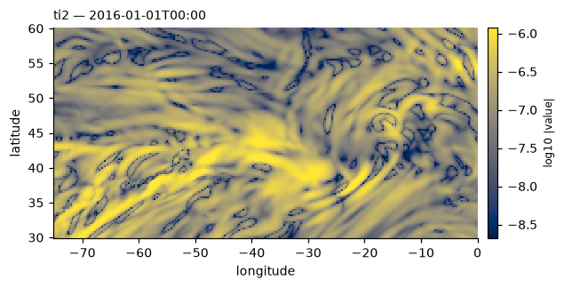

```python
show("ti2", log=True, diverging=False)
```

### 4.20 `f2d`

$$\tfrac{1}{2}\frac{D}{Dt}\left[\left(\frac{\partial u}{\partial \theta}\right)^2 + \left(\frac{\partial v}{\partial \theta}\right)^2\right]$$

Isentropic frontogenesis — the only diagnostic with a time derivative, and the only one whose sign convention is still open (§5).

```
def f2d(s):
    """[20] Isentropic frontogenesis (A9):

        F = 1/2 * D/Dt [ Q ],   Q = (du/dtheta)^2 + (dv/dtheta)^2
        D/Dt = d/dt + u d/dx + v d/dy          (material derivative at 200 hPa)
        du/dtheta = (du/dp) / (dtheta/dp)      (chain rule on the pressure levels)

    d/dt is centred in time (3-hourly), one-sided at the first and last step of
    the file. The variant (convention) decides the sign/magnitude reading.
    """
    variant = s["conv"]["f2d_variant"]
    u, v, theta = s["u"], s["v"], s["theta"]
    Q = (d_dp(u) / d_dp(theta)) ** 2 + (d_dp(v) / d_dp(theta)) ** 2
    scalar = _at(Q, s)
    if variant == "D":
        scalar = np.sqrt(scalar)
    d_dt = scalar.differentiate("time", datetime_unit="s")
    material = d_dt + _at(u, s) * d_dx(scalar, s["geo"]) + _at(v, s) * d_dy(scalar, s["geo"])
    if variant == "A":
        return 0.5 * material
    if variant == "B":
        return -0.5 * material
    if variant == "C":
        return np.abs(0.5 * material)
    if variant == "D":
        return -material
    raise ValueError(f"unknown f2d variant {variant!r}; choose from {sorted(F2D_VARIANTS)}")

median 4.829e-07   p97 7.83e-05   p99.9 0.0004798   NaN 0.00 %
```

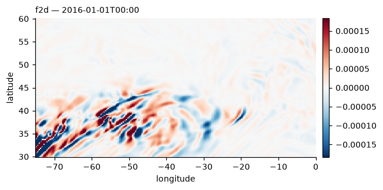

```python
show("f2d", log=False, diverging=True)
```

### 4.21 `ncsu1`

$$\frac{\max\left(u\,\partial u/\partial x + v\,\partial v/\partial y,\,0\right)\;\left|\nabla\zeta\right|}{\max(\mathrm{Ri},\,10^{-5})}$$

Kaplan's index: flow acceleration times a vorticity gradient, divided by stability.

```
def ncsu1(s):
    """[21] NCSU1 (A36, Kaplan et al. 2005):

        NCSU1 = max(u du/dx + v dv/dy, 0) * |grad zeta| / max(Ri, 1e-5)
    """
    geo = s["geo"]
    u, v, zeta = _at(s["u"], s), _at(s["v"], s), _at(s["zeta"], s)
    du_dx, dv_dy = _at(s["wd"]["du_dx"], s), _at(s["wd"]["dv_dy"], s)
    advection = (u * du_dx + v * dv_dy).clip(min=0)
    grad_zeta = np.sqrt(d_dx(zeta, geo) ** 2 + d_dy(zeta, geo) ** 2)
    ri = _at(s["N2"] / s["Sv2"], s)
    return (advection * grad_zeta) / ri.clip(min=C.RI_FLOOR)

median 1.945e-17   p97 4.757e-14   p99.9 4.518e-13   NaN 0.00 %
```

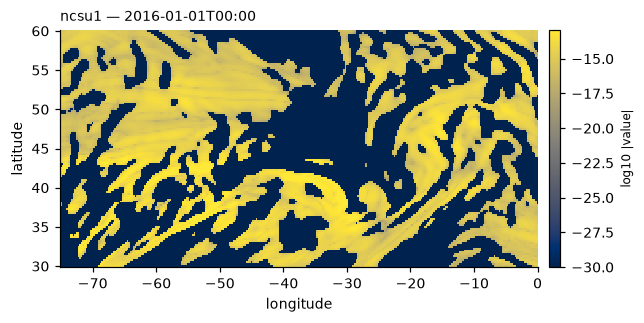

```python
show("ncsu1", log=True, diverging=False)
```

### The 21 at a glance

Maps are on a log scale because the diagnostics span many orders of magnitude — which is also why they are never compared by value, only by percentile (§6).

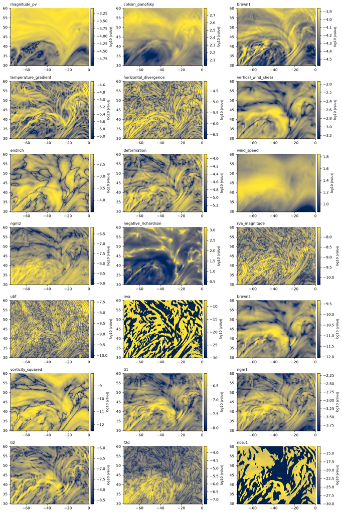

```python
fig, axes = plt.subplots(7, 3, figsize=(12, 18))
for ax, key in zip(axes.ravel(), C.DIAGNOSTIC_KEYS):
    f = fields[key].isel(time=0)
    plot_map(f, key, ax=ax, log=True)
    ax.set_xlabel(""); ax.set_ylabel("")
plt.tight_layout();
```

## 5. The two conventions, side by side

Three implementation choices are not stated by any paper in this literature. Both series on the cluster exist because of them; `config.CONVENTIONS` holds both.

| switch | `baseline` | `audit` |
| --- | --- | --- |
| `dy` — north–south grid spacing | true meridian arc (MetPy/rojak) | map distance $a\,\Delta\varphi$ |
| `fields` — where $\zeta,\delta,\mathrm{PV}$ come from | ERA5's archived fields | computed from $u, v, T, z$, as Prosser did |
| `f2d_variant` — the reading of A9 | $\left\\|\tfrac12 D Q/Dt\right\\|$ | $+\tfrac12 D Q/Dt$ (signed) |

The cell below computes the same day both ways and measures the difference the way the project measures it: not by how much values move, but by **how much of the exceedance set moves** — the cells above the day's own 97th percentile that one convention flags and the other does not. A constant factor moves values and flips nothing.

```python
other = "baseline" if CONVENTION == "audit" else "audit"
fields_other = D.compute_21(prepared, C.CONVENTIONS[other])

rows = []
for key in C.DIAGNOSTIC_KEYS:
    a = fields[key].values.ravel(); b = fields_other[key].transpose(*fields[key].dims).values.ravel()
    ok = np.isfinite(a) & np.isfinite(b)
    a, b = a[ok], b[ok]
    ta, tb = np.percentile(a, 97), np.percentile(b, 97)
    flip = np.mean((a >= ta) ^ (b >= tb)) / max(np.mean((a >= ta) | (b >= tb)), 1e-12)
    with np.errstate(invalid="ignore", divide="ignore"):
        med = np.nanmedian(np.where(a == b, 0.0, np.abs(a - b) / np.abs(b)))
    rows.append((key, np.corrcoef(a, b)[0, 1], med, flip))

print(f"{CONVENTION} vs {other}, one day\n")
print(f"{'diagnostic':24s}{'correlation':>13s}{'median |rel diff|':>19s}{'p97 flip rate':>15s}")
for key, r, med, flip in rows:
    print(f"{key:24s}{r:>13.5f}{med:>19.2%}{flip:>15.2%}")
```

```
audit vs baseline, one day

diagnostic                correlation  median |rel diff|  p97 flip rate
magnitude_pv                  0.99064          10235.99%         57.65%
colson_panofsky               1.00000              0.00%          0.00%
brown1                        0.99988              0.25%          1.86%
temperature_gradient          1.00000              0.07%          0.41%
horizontal_divergence         0.99730              5.20%          7.65%
vertical_wind_shear           1.00000              0.00%          0.00%
endlich                       1.00000              0.00%          0.00%
deformation                   1.00000              0.10%          0.34%
wind_speed                    1.00000              0.00%          0.00%
ngm2                          1.00000              0.10%          0.14%
negative_richardson           1.00000              0.00%          0.00%
rva_magnitude                 0.99093              9.16%         12.34%
ubf                           0.99990              1.09%          1.02%
nva                           0.99187              1.12%         11.53%
brown2                        0.99999              0.25%          0.52%
vorticity_squared             0.99797              2.86%          7.94%
ti1                           1.00000              0.10%          0.16%
ngm1                          1.00000              0.10%          0.27%
ti2                           0.99960              1.92%          2.73%
f2d                          -0.06469             12.06%         71.26%
ncsu1                         0.99807              0.00%          5.58%
```

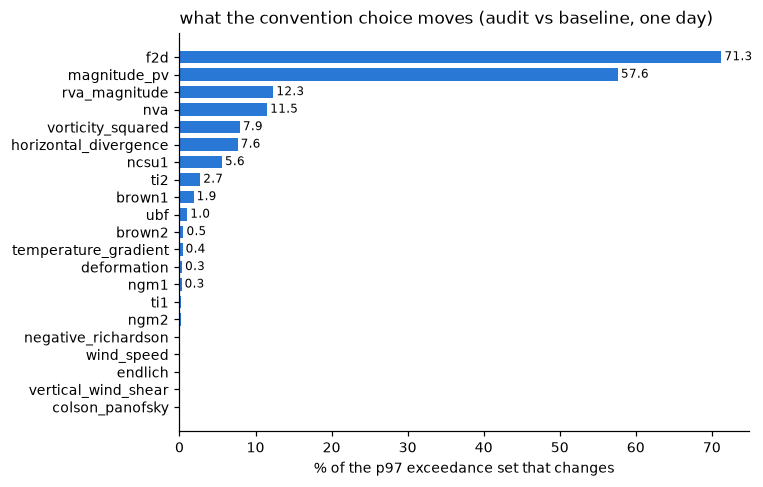

```python
flips = np.array([r[3] for r in rows])
order = np.argsort(flips)
fig, ax = plt.subplots(figsize=(7, 4.5))
ax.barh([rows[i][0] for i in order], 100 * flips[order], color=BLUE, height=0.7)
ax.set_xlabel("% of the p97 exceedance set that changes"); ax.set_title(
    f"what the convention choice moves ({CONVENTION} vs {other}, one day)", loc="left")
for i, v in zip(range(len(order)), 100 * flips[order]):
    if v > 0.2:
        ax.text(v + 0.4, i, f"{v:.1f}", va="center", fontsize=8)
plt.tight_layout();
```

Three things to read out of that table.

**Five diagnostics are bit-identical** — `colson_panofsky`, `endlich`, `negative_richardson`, `vertical_wind_shear`, `wind_speed`. They are exactly the ones with neither a north–south derivative nor an archived field, so none of the three switches can reach them. The same five come out identical in the threshold comparison on the full reference year.

**`f2d` is barely the same ranking** (correlation ≈ 0): the two readings of Sharman A9 differ by an absolute value, which is not a monotone transform. This is the one switch that changes what the diagnostic *is*, and it is why a series from one convention must never be scored against thresholds from the other.

**`magnitude_pv`'s enormous relative difference is a unit factor, not a disagreement.** The computed form differentiates $\theta$ against a pressure coordinate carried in hPa, so it is 100× the SI value; constant factors cancel out of a percentile threshold exactly. Its real change is the 58 % of the exceedance set that moves, because full Ertel PV and Sharman's truncated form are different quantities.

On the full 42 years this choice moves the **levels** (the audit series sits about a fifth closer to Prosser's published exceedance frequencies) and leaves the **trends** alone: all 25 season × severity trends stay significant and keep Prosser's value inside their interval, and no trend ratio moves by more than 0.05. `DECISIONS.md` §3 has the full argument for each side.

## 6. Turning diagnostics into turbulence: the thresholds

The 21 diagnostics have different units and span orders of magnitude, so "turbulent" cannot be a value — it is a **percentile of the diagnostic's own global distribution**. Williams (2017), adopted by Prosser, fixes the ladder:

| severity | light | light-to-moderate | moderate | moderate-to-severe | severe |
| --- | --- | --- | --- | --- | --- |
| percentile | 97.0 | 99.1 | 99.6 | 99.8 | 99.9 |

The percentile is taken over the **whole global year 2000**, every cell and every 3-hourly step, with each cell weighted by the area it represents, $w = \cos\varphi$ (a 0.25° cell near the pole is much smaller than one at the equator). The weighted quantile is the Hazen rule: sort the values, give value $i$ the weight $w_i$, let $C_i$ be the cumulative weight and $W$ the total, place value $i$ at

$$P_i = \frac{C_i - w_i/2}{W}$$

and interpolate the values against $P_i$. With equal weights this is the textbook $(i-\tfrac12)/n$.

A full year is $721\times1440\times2928 \approx 3\times10^9$ values per diagnostic — too many to sort. It does not have to be: everything below a cut enters $P_i$ through a single number, the total weight below it, so one streaming pass that keeps the top ~12 % gives **exactly** the same thresholds. The check below is the demonstration.

```python
source_of(T.weighted_percentile)
```

```
def weighted_percentile(values, weights, percentiles):
    """Weighted Hazen percentiles (percentiles in 0..100). NaNs are dropped."""
    values = np.asarray(values, dtype=np.float64).ravel()
    weights = np.asarray(weights, dtype=np.float64).ravel()
    keep = np.isfinite(values)
    values, weights = values[keep], weights[keep]
    order = np.argsort(values, kind="stable")
    v_unique, inverse = np.unique(values[order], return_inverse=True)
    w_unique = np.zeros(v_unique.shape)
    np.add.at(w_unique, inverse, weights[order])
    position = (np.cumsum(w_unique) - 0.5 * w_unique) / weights.sum()
    q = np.atleast_1d(np.asarray(percentiles, dtype=np.float64) / 100.0)
    return np.interp(q, position, v_unique, left=v_unique[0], right=v_unique[-1])
```

```python
# Exact equality of the streaming tail method and a full sort, on this day's ti1 field.
x = fields["ti1"].transpose("latitude", "longitude", "time").values
w_lat = T.latitude_weights(prepared.latitude.values)
w = np.broadcast_to(w_lat[:, None, None], x.shape)
q = np.array(list(C.SEVERITIES.values()))

full = T.weighted_percentile(x, w, q)
cut = float(T.weighted_percentile(x[:, :, ::7], w[:, :, ::7], [88])[0])
keep = np.isfinite(x) & (x >= cut)
rows_idx = np.broadcast_to(np.arange(w_lat.size, dtype=np.int16)[:, None, None], x.shape)[keep]
finite = np.isfinite(x)
w_total = float(np.dot(w_lat, finite.sum(axis=(1, 2))))
w_below = float(np.dot(w_lat, (finite & ~keep).sum(axis=(1, 2))))
tail, *_ = T.thresholds_from_tail(x[keep], rows_idx, w_lat, w_below, w_total, q, "ti1", 0.005)

print(f"{'severity':22s}{'full sort':>14s}{'tail method':>14s}{'relative difference':>21s}")
for name, a, b in zip(C.SEVERITIES, full, tail):
    print(f"{name:22s}{a:>14.6g}{b:>14.6g}{abs(a-b)/abs(a):>21.1e}")
print(f"\nkept {100*(1-w_below/w_total):.1f} % of the values; the rest enters through one number.")
```

```
severity                   full sort   tail method  relative difference
light                    8.22779e-07   8.22779e-07              7.1e-12
light_to_moderate        1.34241e-06   1.34241e-06              8.3e-12
moderate                 1.75593e-06   1.75593e-06              7.4e-12
moderate_to_severe       2.09831e-06   2.09831e-06              5.6e-11
severe                   2.37376e-06   2.37376e-06              4.4e-11

kept 11.8 % of the values; the rest enters through one number.
```

The real threshold file is `calibration/thresholds_2026-09-11.json` on the cluster (audit) or `…_2026-09-07.json` (baseline). If a copy sits next to the repository the next cell picks it up and the exceedance maps below are the real ones; otherwise the notebook falls back to this day's own percentiles, which is enough to show the mechanism but is **not** the calibration.

```python
THRESHOLD_CANDIDATES = [os.environ.get("CAT_THRESHOLDS", ""),
                        f"../calibration/thresholds_{CONVENTION}.json",
                        "../calibration/thresholds_2026-09-11.json"]
tpath = next((Path(p) for p in THRESHOLD_CANDIDATES if p and Path(p).exists()), None)

if tpath:
    thresholds, _, prov = T.load_thresholds(tpath)
    print("using the calibrated thresholds:", tpath.name, "|", prov.get("period"))
else:
    thresholds = {k: {s: float(np.nanpercentile(fields[k].values, p))
                      for s, p in C.SEVERITIES.items()} for k in C.DIAGNOSTIC_KEYS}
    print("NO calibration file found — using THIS DAY's own percentiles as a stand-in.")
```

```
NO calibration file found — using THIS DAY's own percentiles as a stand-in.
```

## 7. From thresholds to a turbulence frequency, and to a trend

**Exceedance.** For each diagnostic $D$ and severity $s$, a cell at a time step is either flagged or not: $$E_{D,s}(c,t) = \mathbb{1}\left[D(c,t) \ge \tau_{D,s}\right].$$

**The ensemble.** The 21 flags are averaged — *after* thresholding, never before: $$\bar{E}_s(c,t) = \frac{1}{21}\sum_D E_{D,s}(c,t).$$ A cell where 8 of the 21 diagnostics agree is 0.38, not "no turbulence".

**The frequency.** Averaged over Prosser's box (36–60°N, 55–10°W) and every step of a season, area-weighted: $$P_s(Y) = \frac{\sum_{c,t} w_c\,\bar{E}_s(c,t)}{\sum_{c,t} w_c}.$$ Times $24\times$ the days in the season, this is "hours of turbulence at an average point", the unit of Prosser's Table 1.

**The trend** is then an ordinary least-squares line through the 42 annual values.

```
area-weighted frequency over this day and this box: 0.432%
```

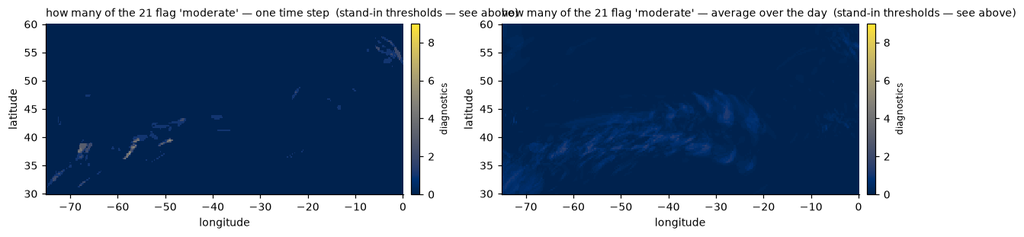

```python
sev = "moderate"
exceed = []
for key in C.DIAGNOSTIC_KEYS:
    f = fields[key]
    exceed.append(((f >= thresholds[key][sev]).astype(float)).where(f.notnull()))
ensemble = xr.concat(exceed, dim="diagnostic").mean("diagnostic", skipna=True)

note = "" if tpath else "  (stand-in thresholds — see above)"
count = 21 * ensemble
fig, axes = plt.subplots(1, 2, figsize=(11, 2.9))
for ax, f, ttl in [(axes[0], count.isel(time=0), f"one time step{note}"),
                   (axes[1], count.mean("time"), f"average over the day{note}")]:
    im = ax.pcolormesh(f.longitude, f.latitude, f.values, vmin=0, vmax=float(count.max()),
                       cmap="cividis", shading="auto", rasterized=True)
    ax.set_title(f"how many of the 21 flag '{sev}' — {ttl}", fontsize=9, loc="left")
    ax.set_xlabel("longitude"); ax.set_ylabel("latitude")
    plt.colorbar(im, ax=ax, pad=0.02, fraction=0.045).set_label("diagnostics", fontsize=8)
w = xr.DataArray(T.latitude_weights(prepared.latitude), dims="latitude").broadcast_like(ensemble)
print(f"area-weighted frequency over this day and this box: "
      f"{float((ensemble*w).sum()/w.where(ensemble.notnull()).sum()):.3%}")
plt.tight_layout();
```

### The 42-year result

These are the numbers already computed on the cluster — read from `data_prosser/`, not recomputed. The series is the area-weighted annual moderate-or-greater frequency in Prosser's box, 1979–2020, and the line is `trends.ols`, the same fit the pipeline reports.

```
fitted change +36.2%   t = 5.36   R2 = 0.42   Prosser +37%   ratio 0.98
```

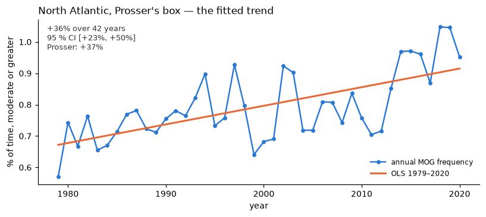

```python
import csv
series_path = next((Path(p) for p in [os.environ.get("CAT_SERIES", ""),
                                      "../data_prosser/per_diagnostic_annual_moderate_series.csv"]
                    if p and Path(p).exists()), None)
with open(series_path) as fh:
    table = list(csv.DictReader(fh))
years = np.array([int(r["year"]) for r in table], float)
ens = np.array([float(r["ensemble"]) for r in table])

fit = TR.trend_row(years, ens)
line = TR.ols(years, ens)
prosser = C.PROSSER_TABLE1["annual"]["moderate"][2]

fig, ax = plt.subplots(figsize=(7.5, 3.4))
ax.plot(years, 100 * ens, color=BLUE, lw=1.6, marker="o", ms=3.5, label="annual MOG frequency")
ax.plot(years, 100 * (line["slope"] * years + line["intercept"]), color=ORANGE, lw=2,
        label="OLS 1979–2020")
ax.set_ylabel("% of time, moderate or greater"); ax.set_xlabel("year")
ax.set_title("North Atlantic, Prosser's box — the fitted trend", loc="left")
ax.legend(frameon=False, fontsize=8)
ax.annotate(f"{fit['change']:+.0%} over 42 years\n95 % CI [{fit['ci_lo']:+.0%}, {fit['ci_hi']:+.0%}]"
            f"\nProsser: {prosser:+.0%}", xy=(0.02, 0.97), xycoords="axes fraction",
            va="top", fontsize=8.5, color="#333333")
plt.tight_layout()
print(f"fitted change {fit['change']:+.1%}   t = {fit['t']:.2f}   R2 = {fit['r2']:.2f}   "
      f"Prosser {prosser:+.0%}   ratio {fit['change']/prosser:.2f}")
```

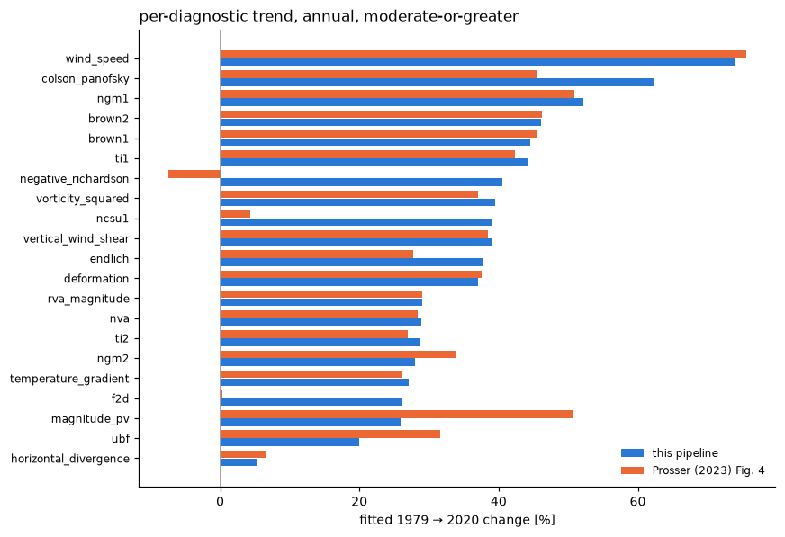

```python
# Every diagnostic's own fitted trend, against Prosser's published panel values.
vs = Path("../data_prosser/per_diagnostic_vs_prosser.csv")
if vs.exists():
    with open(vs) as fh:
        rows_p = list(csv.DictReader(fh))
    rows_p.sort(key=lambda r: float(r["ours_change_pct"]))
    names = [r["diagnostic"] for r in rows_p]
    y = np.arange(len(names))
    fig, ax = plt.subplots(figsize=(8, 5.5))
    ax.barh(y - 0.2, [float(r["ours_change_pct"]) for r in rows_p], height=0.38,
            color=BLUE, label="this pipeline")
    ax.barh(y + 0.2, [float(r["prosser_change_pct"]) for r in rows_p], height=0.38,
            color=ORANGE, label="Prosser (2023) Fig. 4")
    ax.set_yticks(y, names, fontsize=8)
    ax.axvline(0, color=GREY, lw=1)
    ax.set_xlabel("fitted 1979 → 2020 change [%]")
    ax.set_title("per-diagnostic trend, annual, moderate-or-greater", loc="left")
    ax.legend(frameon=False, fontsize=8)
    plt.tight_layout()
```

## 8. Why you can believe the numbers

`essentials/` was written to be readable, and then checked against the code that actually produced the dataset (rojak @ `25b8685` plus `2_diagnostics.py`, through `ada/diagnostics_global.py`). Every check below is a script in `essentials/tests/`.

| check | result |
| --- | --- |
| 21 diagnostics, real ERA5 day, `baseline` / `audit` / the Endlich variant | **every value bit-identical** |
| same, 3-day file (so the time derivative crosses a chunk boundary) | bit-identical |
| same, the small NetCDF subset in this repo | bit-identical |
| same, a synthetic global grid (poles, 0–360° longitudes) | bit-identical |
| 1-day / 2-day chunking against processing the whole file at once | identical |
| thresholds, against `ada/tail_thresholds.py` | identical JSON |
| streaming tail method against a full sort | $\le 2\times10^{-8}$ relative |
| exceedance frequencies, against `aggregate.py` + `full_trend_check.py` | $7\times10^{-16}$ relative |
| the OLS fit | identical |
| geometry against exact ellipsoidal gradients, scale factors against the closed form, the angle wrap, the Hazen rule, the calibration guard | pass |

On the cluster the same comparison can be run against the stores themselves: `sbatch essentials/jobs/0_check_against_original.sbatch` recomputes 1979-01 under both conventions and compares it with the production stores, and `sbatch --export=ALL,CONVENTION=audit essentials/jobs/0b_check_thresholds_and_trends.sbatch` re-derives the thresholds and the 42-year trend table from the stores that already exist.

## 9. Where everything is

| file | what it holds |
| --- | --- |
| `config.py` | every constant and path; the two conventions |
| `download.py` | the CDS request, the integrity check, the atomic write |
| `diagnostics.py` | the geometry, the operators and the 21 formulas (§2–§4 above) |
| `thresholds.py` | the weighted percentiles and the streaming tail method (§6) |
| `trends.py` | exceedance, seasonal frequencies, the OLS trend (§7) |
| `main.py` | one command line for all four stages, plus the comparisons |
| `jobs/` | the SLURM scripts, with the measured memory and wall-clock in the header |
| `tests/` | the checks in §8 |
| `DECISIONS.md` | every choice: what, why, the source, and where in the code |

The dataset itself is unchanged and stays on the share: `derived/north_atlantic_audit/` (504 months) with `calibration/thresholds_2026-09-11.json`, and the baseline pair beside it.